# Exam Inventory Management

summer term 2020

Thomas Kirschstein

This is the exam for the course “Inventory Management” for the summer term 2020. In total 60 points are distributed to 3 tasks. When solving a task completely and correctly, 20 points are credited. Subtasks are annotated with the corresponding number of points. Thus, all tasks have to be solved to reach all points. Allowed auxiliary materials are a) a calculator, and b) one sheet of paper (DIN A4 format), handwritten (potentially on both sides). In all calculations round to 3 digits (if necessary).

Good luck!

# Task 1: MRP

The company “LeftWing” produces of drones. The start-up is launching an automated cellular production system. The associated management system is to be set up with the production related data. Therefore, the systems output is compared to the by-hand calculation of next weeks material requirement plan. The two main products are called “Enduro” (End) and “Star” (Sta) of which 37 and 22 units are ordered for the next week, respectively. Inventory records for the raw materials (M1,…,M4) and components (C1,…,C3) are as follows:

| material id | M1 | M2 | M3 | M4 | C1 | C2 | C3 | End | Sta |
| --- | --- | --- | --- | --- | --- | --- | --- | --- | --- |
| inventory level | 12 | 50 | 25 | 30 | 17 | 23 | 8 | 3 | 7 |

The assembly processes are shown in the following matrix of direct production coefficients:

```
##     End Sta C1 C2 C3 M1 M2 M3 M4
## End   0   0  0  0  0  0  0  0  0
## Sta   0   0  0  0  0  0  0  0  0
## C1    1   0  0  1  1  0  0  0  0
## C2    1   2  0  0  0  0  0  0  0
## C3    0   0  0  1  0  0  0  0  0
## M1    0   0  5  0  0  0  0  0  0
## M2    1   0  3  2  1  0  0  0  0
## M3    1   3  0  4  0  0  0  0  0
## M4    0   3  0  0  2  0  0  0  0
```

1. Help the management and draw a tree graph of the production process. Determine the production stages of each material. (*8 points*)

[figure not shown]

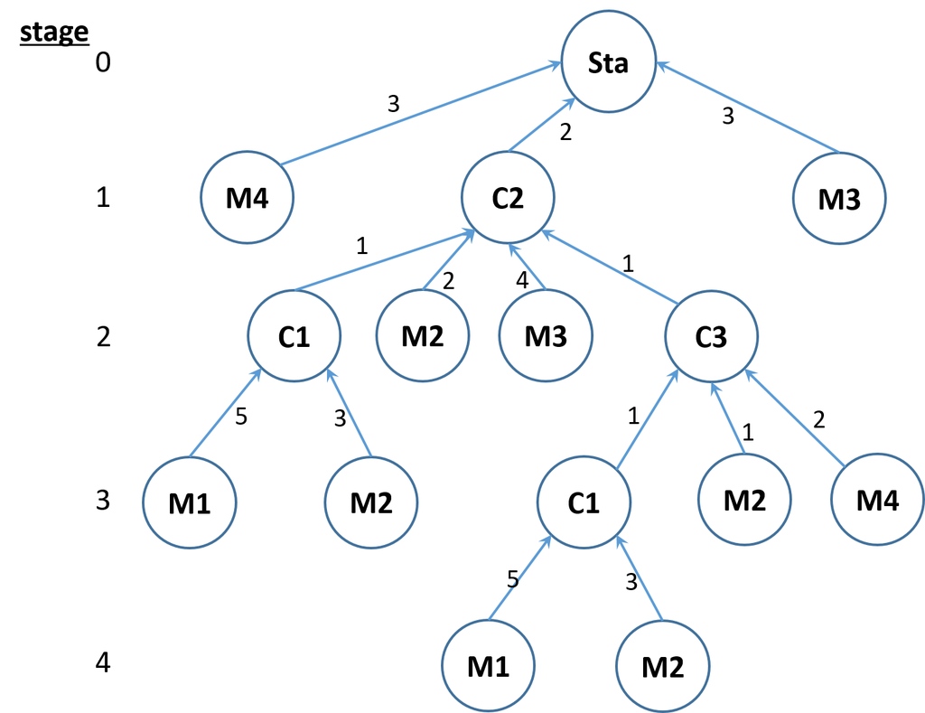

2. Deduce the Gozinto graph of the production process and calculate the net demand of all materials. (*12 points*)

[figure not shown]

Gozinto graph